# Berry_Classif-checkpoint

## Berry vs Grape Image Classification

*This notebook is largely based on [this tutorial](https://github.com/fastai/course-v3/blob/master/nbs/dl1/lesson2-download.ipynb) from [fast.ai](https://www.fast.ai/)*

What it aims to do is classify a picture of berries as blue, black or grapes. This is just so I can see how good it can become at differentiating between similar looking images.

```python
from fastai.vision import *
```

**Get images from google**

1. Search Google Images & load all the images you want
2. Enter the following code after pressing `cmd-Opt-j`

   > `urls=Array.from(document.querySelectorAll('.rg_i')).map(el=> el.hasAttribute('data-src')?el.getAttribute('data-src'):el.getAttribute('data-iurl'));`  
   > `window.open('data:text/csv;charset=utf-8,' + escape(urls.join('\n')));`

**Create directories for images**

```python
folder = 'blue'
file = 'blueberries.csv'
```

```python
path = Path('data/berries')
dest = path/folder
dest.mkdir(parents=True, exist_ok=True)
```

```python
folder = 'grape'
file = 'grapes.csv'
```

```python
path = Path('data/berries')
dest = path/folder
dest.mkdir(parents=True, exist_ok=True)
```

```python
folder = 'black'
file = 'blackberries.csv'
```

```python
path = Path('data/berries')
dest = path/folder
dest.mkdir(parents=True, exist_ok=True)
```

```python
path.ls()
```

```
[PosixPath('data/berries/black'),
 PosixPath('data/berries/grape'),
 PosixPath('data/berries/blue')]
```

```python
classes = ['blue','grape','black']
```

*Next, place the* **csv files** *into the* **directory**

**Downloading the Images**

*Note: If it doesn't work the first time, add max_workers = 0 to debug*

```python
path = Path('data/berries')
folder = 'blue'
file = 'blueberries.csv'
dest = path/folder
download_images(path/file, dest, max_pics=200)

path = Path('data/berries')
folder = 'grape'
file = 'grapes.csv'
dest = path/folder
download_images(path/file, dest, max_pics=200)

path = Path('data/berries')
folder = 'black'
file = 'blackberries.csv'
dest = path/folder
download_images(path/file, dest, max_pics=200)
```

**Cleaning up the images**

```python
for c in classes:
    print(c)
    verify_images(path/c, delete=True, max_size=500)
```

```
blue
```

```
grape
```

```
black
```

**Loading the images as data**

```python
np.random.seed(42)
data = ImageDataBunch.from_folder(path, train=".", valid_pct=0.2,
        ds_tfms=get_transforms(), size=224, num_workers=2).normalize(imagenet_stats)
```

```python
data.classes
```

```
['black', 'blue', 'grape']
```

[figure not shown]

```python
data.show_batch(rows=3, figsize=(7,8))
```

```python
data.classes, data.c, len(data.train_ds), len(data.valid_ds)
```

```
(['black', 'blue', 'grape'], 3, 480, 120)
```

**Train Model**

```python
model = cnn_learner(data, models.resnet34, metrics=error_rate)
```

```python
model.fit_one_cycle(4)
```

| epoch | train_loss | valid_loss | error_rate | time |
| --- | --- | --- | --- | --- |
| 0 | 1.577304 | 1.205097 | 0.375000 | 00:06 |
| 1 | 1.053187 | 0.694695 | 0.208333 | 00:04 |
| 2 | 0.793971 | 0.686841 | 0.183333 | 00:04 |
| 3 | 0.643583 | 0.658043 | 0.191667 | 00:04 |

```python
model.save('model-1')
```

*The model appears to have a learning rate that is too low as the validation loss is greater than the training loss at points, indicating that we aren't fitting the data enough*

```python
model.unfreeze()
```

```python
model.lr_find()
```

66.67% [10/15 00:49<00:24]

| epoch | train_loss | valid_loss | error_rate | time |
| --- | --- | --- | --- | --- |
| 0 | 0.207920 | #na# | 00:05 |  |
| 1 | 0.218938 | #na# | 00:04 |  |
| 2 | 0.265208 | #na# | 00:05 |  |
| 3 | 0.263875 | #na# | 00:04 |  |
| 4 | 0.241754 | #na# | 00:04 |  |
| 5 | 0.224691 | #na# | 00:04 |  |
| 6 | 0.195078 | #na# | 00:04 |  |
| 7 | 0.272349 | #na# | 00:04 |  |
| 8 | 0.416401 | #na# | 00:04 |  |
| 9 | 0.640760 | #na# | 00:04 |  |

14.29% [1/7 00:01<00:07 0.6865]

```
LR Finder is complete, type {learner_name}.recorder.plot() to see the graph.
```

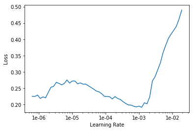

```python
model.recorder.plot()
```

```python
model.fit_one_cycle(3, max_lr=slice(5e-5,1e-4))
```

| epoch | train_loss | valid_loss | error_rate | time |
| --- | --- | --- | --- | --- |
| 0 | 0.255047 | 0.645228 | 0.158333 | 00:05 |
| 1 | 0.212066 | 0.602439 | 0.166667 | 00:05 |
| 2 | 0.164279 | 0.601028 | 0.166667 | 00:05 |

```python
model.save('model-2')
```

Our model with the lowest error_rate appears to be model 2.  
**Let's load this model and see what the results indicate.**

```python
model.load('model-2');
```

```python
interp = ClassificationInterpretation.from_learner(model)
```

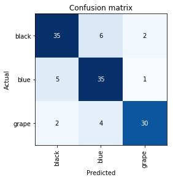

```python
interp.plot_confusion_matrix()
```

*It appears that our model has a tough time with some blue and black berries.* *Let's visualize some of these errors*

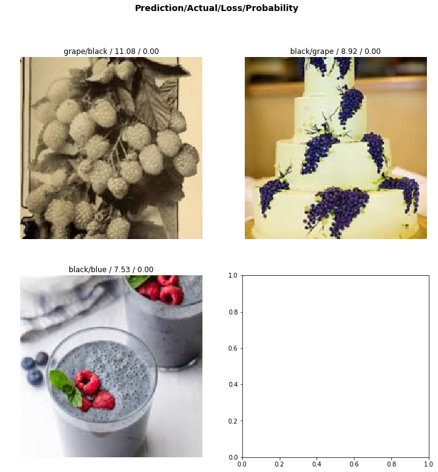

```python
interp.plot_top_losses(k=3)
```

*As we can see, some of these make sense as they are really noisy photos... let's clean up the photos and then, see how our model performs*

### Cleaning Up

```python
from fastai.widgets import *
```

```python
#not quite sure what this is doing
db = (ImageList.from_folder(path)
                   .split_none()
                   .label_from_folder()
                   .transform(get_transforms(), size=224)
                   .databunch()
     )
```

```python
learn_cln = cnn_learner(db, models.resnet34, metrics=error_rate)
learn_cln.load('model-2');
```

```python
#not sure what this does
ds, idxs = DatasetFormatter().from_toplosses(learn_cln)
```

```python
ImageCleaner(ds, idxs, path)
```

*Now that we have cleaned our dataset, we must recreate our model from the cleaned.csv file*

```python
path = Path('data/berries')
np.random.seed(42)
cleaned_data = ImageDataBunch.from_csv(path, size=224, valid_pct=0.2,
    ds_tfms=get_transforms(), csv_labels='cleaned.csv').normalize(imagenet_stats)
```

```python
cleaned_data.classes
```

```
['black', 'blue', 'grape']
```

```python
cleaned_data.classes, cleaned_data.c, len(cleaned_data.train_ds), len(cleaned_data.valid_ds)
```

```
(['black', 'blue', 'grape'], 3, 466, 116)
```

```python
clean_model = cnn_learner(cleaned_data, models.resnet34, metrics=error_rate)
```

```python
clean_model.fit_one_cycle(4)
```

| epoch | train_loss | valid_loss | error_rate | time |
| --- | --- | --- | --- | --- |
| 0 | 1.386402 | 0.772207 | 0.293103 | 00:05 |
| 1 | 0.963616 | 0.325445 | 0.094828 | 00:05 |
| 2 | 0.713280 | 0.268121 | 0.086207 | 00:04 |
| 3 | 0.592865 | 0.271233 | 0.068966 | 00:05 |

```python
clean_model.save('model-1')
```

```python
clean_model.load('model-1');
```

```python
clean_model.unfreeze()
```

```python
clean_model.lr_find(start_lr=1e-5, end_lr=1e-1)
```

66.67% [10/15 00:53<00:26]

| epoch | train_loss | valid_loss | error_rate | time |
| --- | --- | --- | --- | --- |
| 0 | 0.261799 | #na# | 00:05 |  |
| 1 | 0.239894 | #na# | 00:05 |  |
| 2 | 0.216484 | #na# | 00:05 |  |
| 3 | 0.178421 | #na# | 00:05 |  |
| 4 | 0.150489 | #na# | 00:05 |  |
| 5 | 0.147393 | #na# | 00:05 |  |
| 6 | 0.175543 | #na# | 00:05 |  |
| 7 | 0.251147 | #na# | 00:05 |  |
| 8 | 0.466977 | #na# | 00:05 |  |
| 9 | 0.541273 | #na# | 00:05 |  |

28.57% [2/7 00:02<00:05 0.5590]

```
LR Finder is complete, type {learner_name}.recorder.plot() to see the graph.
```

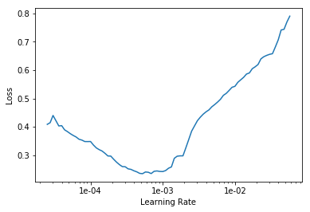

```python
clean_model.recorder.plot()
```

```python
clean_model.fit_one_cycle(3, max_lr=slice(5e-5,1e-4))
```

| epoch | train_loss | valid_loss | error_rate | time |
| --- | --- | --- | --- | --- |
| 0 | 0.245183 | 0.227542 | 0.060345 | 00:06 |
| 1 | 0.219885 | 0.253150 | 0.060345 | 00:06 |
| 2 | 0.200832 | 0.251317 | 0.060345 | 00:06 |

```python
clean_model.save('model-2')
```

*So it appears our best error_rate is 0.06, so about 1/18 will be classified wrong while randomly 12/18 would be classified wrong, so this is't a pretty good result.*

### Let's put it into use

We are going to use it to check if the blue-berries in my fridge are real blue-berries.

```python
clean_model.export()
```

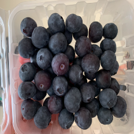

```python
img = open_image(path/'test.png')
img = img.resize(224)
img
```

```python
img2 = open_image(path/'test2.png')
img2 = img2.resize(224)
img2
```

[output not shown]

```python
learn = load_learner(path)
```

```python
pred_class,pred_idx,outputs = learn.predict(img)
pred_class
```

```
Category tensor(1)
```

```python
data.classes
```

```
['black', 'blue', 'grape']
```

**Thus this predicted the image correctly as blue-berries... pretty cool!**